# Hw5 - Housing Subsidy

Gabriel Hernandez

2023-12-11

```r
housingSubsidy <- read.csv("https://github.com/urbanSpatial/Public-Policy-Analytics-Landing/raw/master/DATA/Chapter6/housingSubsidy.csv")
```

# Purpose of Study (motivation paragraph)

The Department of Housing and Community Development (HCD) in Emil City currently has a program which provides home repair tax credits to eligible residents. We know that home repair loans are associated with benefits for both the owner of the real estate and the surrounding properties. This implies an increase in benefits to the community. This tax program has been around for almost 20 years, but there is broad consensus among HCD staff that uptake to join the program is lower than it should be. HCD believes that the uptake is low because HCD currently contacts callers at random.

Using outcomes as our dependent variable we will create a model that predicts the likelihood of credit uptake from the client-level data collected by the department. We will then combine our model with cost-benefit assumptions to develop a decision-making tool for the department that outperforms their at random approach. Furthermore the tool will allow us to predict for every member the probability that they will take the subsidy conditional on their characteristics, and these probabilities we determine who gets sent the offer.

Again, the idea behind the model will be to optimize the bottom line for Total Revenue and public interest (credits used).

# Data exploration (data visualizations that describe feature importance/correlation)

The outcome that we are interested in is binary (yes or no). Useful indicators in our model will be those that exhibit significant differences in the dependent variables outcome. This analysis will use existing data from HCD’s home repair tax credit program. The data contains variables that encompass the characteristics of homeowners in the program, broader economic factors, and most importantly: whether a homeowners took the credit.

Thus, our data contains both categorical and continuous variables. Several continuous variables appeared to be more strongly correlated with credit uptake. These were:

- **Age** - Older clinets were associated with higher chances of credit uptake
- **Unemployment rate** - Low unemployment rates were associated with higher likelihoods of uptake
- **Inflation rate** - Lower inflation is associated with higher likelihood
- **Number of contacts prior to campaign** - Higher number of prior contacts associated with higher likelihood
- **Number of contacts during the campaign** - Lower number of contacts associated with higher likelihood
- **Number of days since contact in a prior program** - Lower number of days associated with higher likelhood

Other variables did not appear to have strong relationships with credit uptake likelihood, so we omitted them from the following visualization.

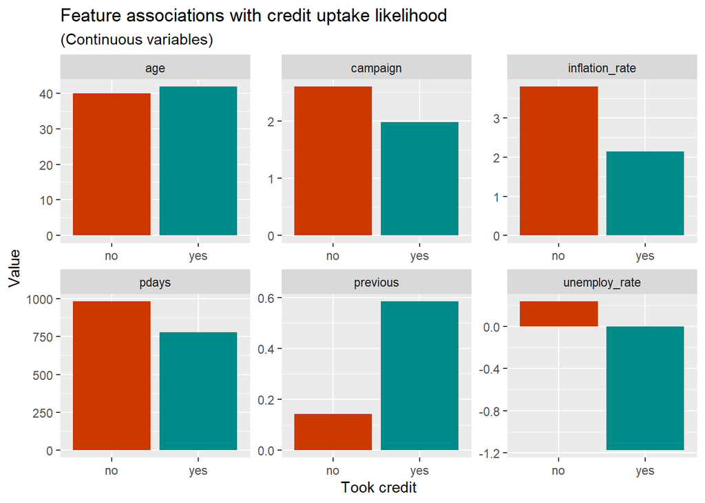

```r
housingSubsidy %>%
  dplyr::select(y, age, unemploy_rate, inflation_rate, previous, pdays, campaign) %>%
  gather(Variable, value, -y) %>%
    ggplot(aes(y, value, fill=y)) +
      geom_bar(position = "dodge", stat = "summary", fun = "mean") +
      facet_wrap(~Variable, scales = "free") +
      scale_fill_manual(values = palette2) +
      labs(x="Took credit", y="Value",
           title = "Feature associations with credit uptake likelihood",
           subtitle = "(Continuous variables)") +
      theme(legend.position = "none")
```

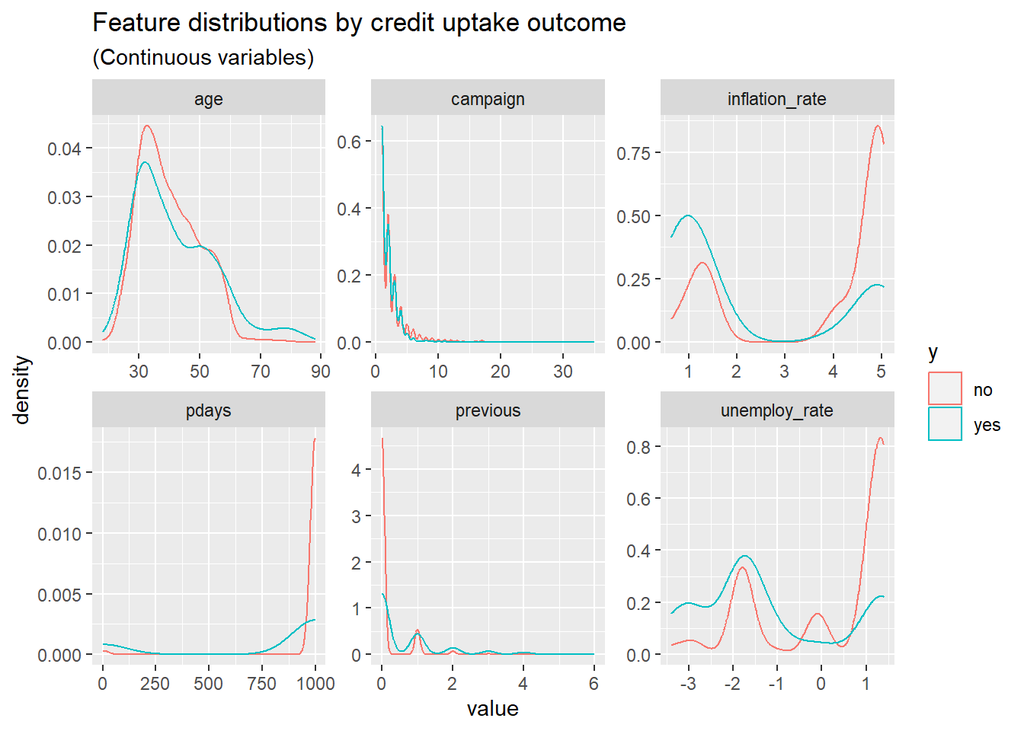

```r
housingSubsidy %>%
    dplyr::select(y, age, unemploy_rate, inflation_rate, previous, pdays, campaign) %>%
    gather(Variable, value, -y) %>%
    ggplot() +
    geom_density(aes(value, color=y), fill = "transparent") +
    facet_wrap(~Variable, scales = "free") +
    scale_fill_manual(values = palette2) +
    labs(title = "Feature distributions by credit uptake outcome",
         subtitle = "(Continuous variables)")
```

## Categorical variables

Among categorical variables we focused on the following: method of contact (cellular), month of contact (December, March, October, September), previous outreach outcome (success), and employment status. Each of these variables appeared to have associations with credit uptake likelihoods, but we omitted others from this visualization because they did not imply a significant relationship with our outcome.

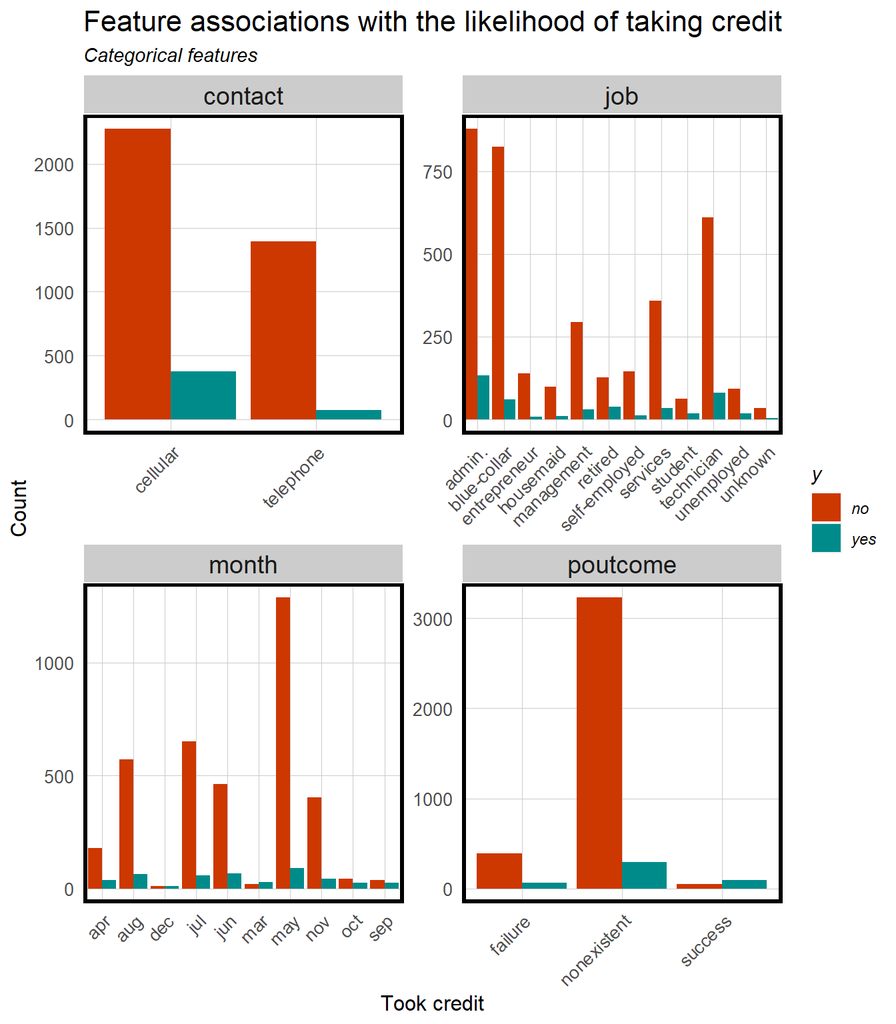

```r
housingSubsidy %>%
  dplyr::select(y, job, month, poutcome, contact) %>%
  gather(Variable, value, -y) %>%
  count(Variable, value, y) %>%
  ggplot(aes(value, n, fill = y)) +
    geom_bar(position = "dodge", stat="identity") +
    facet_wrap(~Variable, scales="free") +
    scale_fill_manual(values = palette2) +
    labs(x="Took credit", y="Count",
         title = "Feature associations with the likelihood of taking credit",
         subtitle = "Categorical features") +
    plotTheme() + theme(axis.text.x = element_text(angle = 45, hjust = 1))
```

#Logistic Regression and Confusion Matrix Split Data

The following code splits our data into a training and test set so that we can create and diagnose our model’s performance.

```r
set.seed(888)
trainIndex <- createDataPartition(housingSubsidy$y, p = .65,
                                  list = FALSE,
                                  times = 1)
training <- housingSubsidy[ trainIndex,]
test <- housingSubsidy[-trainIndex,]
```

## New features in one paragraph

A model with all the possible variables collected per person – a “kitchen sink” model – will yield a lower proportion of True Positive values in our prediction, so we engineered new features in an attempt to improve our model’s sensitivity. We noted that a client’s job and previous outreach outcome result benefits from data cleaning and category simplification. Therefore, we collapsed client jobs down to whether or not they were employed. We also simplified previous outcomes to “success” and “no success”.

We observed the density distributions of continuous variables compared to credit uptake outcomes and visually estimated values at which to set cut-off thresholds for classification. We build these classifications for inflation rate (high/low), last contact (past week, 1-2 weeks, >2 weeks, n/a), age (older/younger than 60), and the amount that a client has already spent on repairs (more/less than $5,150). This introduced a bias into our model and would be a good place to start working back from to improve our model.

```r
housingSubsidy <- housingSubsidy %>%
  mutate(employed = case_when(job == "retired" | job == "student" | job == "unemployed" ~ "not employed",
                              TRUE ~ "employed"),
         poutcome.suc = ifelse(poutcome=="success", 1, 0),
         inflation.high = ifelse(inflation_rate>=3.5, 1, 0),
         last.contact = case_when(pdays == 999 ~ "First contact",
                                  pdays < 7 ~ "Past week",
                                  pdays >= 7 & pdays < 14 ~ "1-2 weeks",
                                  TRUE ~ ">2 weeks"),
         older = ifelse(age > 60, 1, 0),
         spent.less = ifelse(spent_on_repairs > 5150, 1, 0))


trainIndex <- createDataPartition(housingSubsidy$y, p = .65,
                                  list = FALSE,
                                  times = 1)
training <- housingSubsidy[ trainIndex,]
test <- housingSubsidy[-trainIndex,]
```

## Regression Summaries: Kitchen Sink and Engineered Features

We ran both models and summarized the results.

A logistic regression is used to predict the probability that an observation is part of a particular group based on the conditional features in the model. The model is based on a maximum likelihood estimation, which fits an S shaped logistic curve where the predicted probabilities are plotted along the fitted line. In the summaries below, the logistic regression coefficients are on the scale of ‘log-odds ratio’ and must be exponentiated to get the ‘odds ratio.’

The selected features model improves on the kitchen sink model. It lowered the Akaike Information Criterion (AIC). It also possesses significant predictors at a 0.05 significance level. However, none of the newly engineered features were significant. We could do a better job finding out what indicators exist in the dataframe, and consiering what could be brought in. To help with this process, HCD may consider interviewing clients that used the subsidy, and/or local community stakeholders in order to identify nuances that lead to the use of the subsidy.

```r
kitchensinkModel <- glm(y_numeric ~ .,
                  data=training %>%
                    dplyr::select(-X, -y, -education, -taxLien,
                                  -employed, -poutcome.suc,
                                  -last.contact, -inflation.high, -older,
                                  -spent.less),
                  family="binomial" (link="logit"))

summary(kitchensinkModel)
```

```
##
## Call:
## glm(formula = y_numeric ~ ., family = binomial(link = "logit"),
##     data = training %>% dplyr::select(-X, -y, -education, -taxLien,
##         -employed, -poutcome.suc, -last.contact, -inflation.high,
##         -older, -spent.less))
##
## Coefficients:
##                         Estimate   Std. Error z value  Pr(>|z|)
## (Intercept)         -204.8964252  127.2170134  -1.611   0.10727
## age                    0.0198150    0.0084036   2.358   0.01838 *
## jobblue-collar        -0.4962923    0.2375228  -2.089   0.03667 *
## jobentrepreneur       -0.7147595    0.5100138  -1.401   0.16108
## jobhousemaid          -0.7041567    0.5103517  -1.380   0.16766
## jobmanagement         -0.5243978    0.3040194  -1.725   0.08455 .
## jobretired            -0.6623617    0.3809989  -1.738   0.08212 .
## jobself-employed      -0.5864251    0.4141468  -1.416   0.15678
## jobservices           -0.1068504    0.2717362  -0.393   0.69416
## jobstudent            -0.2138808    0.4213927  -0.508   0.61176
## jobtechnician         -0.0827200    0.2259413  -0.366   0.71428
## jobunemployed          0.0901500    0.3855594   0.234   0.81513
## jobunknown             0.0109308    0.7015658   0.016   0.98757
## maritalmarried         0.2829377    0.2560352   1.105   0.26913
## maritalsingle          0.3250548    0.2927695   1.110   0.26688
## maritalunknown       -12.6808795  318.0670910  -0.040   0.96820
## mortgageunknown       -0.5792135    0.5370441  -1.079   0.28080
## mortgageyes           -0.2071847    0.1493196  -1.388   0.16528
## taxbill_in_phlyes     -0.1199925    0.1949315  -0.616   0.53818
## contacttelephone      -0.9101786    0.2821606  -3.226   0.00126 **
## monthaug              -0.1907609    0.4479090  -0.426   0.67019
## monthdec               0.0913295    0.7512615   0.122   0.90324
## monthjul              -0.0087224    0.3740681  -0.023   0.98140
## monthjun              -0.1134761    0.4506649  -0.252   0.80120
## monthmar               2.3866972    0.5545854   4.304 0.0000168 ***
## monthmay              -0.5038803    0.3195284  -1.577   0.11481
## monthnov              -0.5530754    0.4408852  -1.254   0.20967
## monthoct              -0.0351692    0.5457262  -0.064   0.94862
## monthsep               0.0308822    0.6439074   0.048   0.96175
## day_of_weekmon         0.0419574    0.2292381   0.183   0.85477
## day_of_weekthu         0.0838539    0.2349363   0.357   0.72115
## day_of_weektue         0.1048956    0.2363722   0.444   0.65721
## day_of_weekwed         0.2155383    0.2392007   0.901   0.36755
## campaign              -0.0629779    0.0423714  -1.486   0.13719
## pdays                 -0.0001928    0.0007966  -0.242   0.80878
## previous               0.1898115    0.2174683   0.873   0.38276
## poutcomenonexistent    0.6703324    0.3506832   1.912   0.05594 .
## poutcomesuccess        1.5290640    0.7884496   1.939   0.05246 .
## unemploy_rate         -1.1466663    0.4869979  -2.355   0.01854 *
## cons.price.idx         1.8916086    0.8409992   2.249   0.02450 *
## cons.conf.idx          0.0553407    0.0280211   1.975   0.04827 *
## inflation_rate         0.0157758    0.4513520   0.035   0.97212
## spent_on_repairs       0.0052537    0.0103287   0.509   0.61099
## ---
## Signif. codes:  0 '***' 0.001 '**' 0.01 '*' 0.05 '.' 0.1 ' ' 1
##
## (Dispersion parameter for binomial family taken to be 1)
##
##     Null deviance: 1853.7  on 2678  degrees of freedom
## Residual deviance: 1389.1  on 2636  degrees of freedom
## AIC: 1475.1
##
## Number of Fisher Scoring iterations: 13
```

```r
selectModel <- glm(y_numeric ~ .,
                  data=training %>%
                    dplyr::select(-X, -y,
                                  -job, -taxbill_in_phl, -poutcome,
                                  -marital, -education, -mortgage, -day_of_week,
                                  -taxLien, -pdays, -inflation_rate, -spent_on_repairs),
                  family="binomial" (link="logit"))

summary(selectModel)
```

```
##
## Call:
## glm(formula = y_numeric ~ ., family = binomial(link = "logit"),
##     data = training %>% dplyr::select(-X, -y, -job, -taxbill_in_phl,
##         -poutcome, -marital, -education, -mortgage, -day_of_week,
##         -taxLien, -pdays, -inflation_rate, -spent_on_repairs))
##
## Coefficients:
##                              Estimate  Std. Error z value   Pr(>|z|)
## (Intercept)               -140.102515   31.841149  -4.400 0.00001082 ***
## age                          0.010007    0.007375   1.357    0.17484
## contacttelephone            -0.813035    0.263349  -3.087    0.00202 **
## monthaug                    -0.098181    0.403210  -0.243    0.80762
## monthdec                     0.084458    0.711444   0.119    0.90550
## monthjul                     0.146670    0.372842   0.393    0.69404
## monthjun                     0.116031    0.384836   0.302    0.76303
## monthmar                     2.265886    0.476120   4.759 0.00000194 ***
## monthmay                    -0.479107    0.292810  -1.636    0.10179
## monthnov                    -0.603139    0.504438  -1.196    0.23183
## monthoct                    -0.041949    0.460677  -0.091    0.92744
## monthsep                     0.023087    0.490463   0.047    0.96246
## campaign                    -0.061512    0.042615  -1.443    0.14889
## previous                    -0.172955    0.135684  -1.275    0.20242
## unemploy_rate               -0.929197    0.390406  -2.380    0.01731 *
## cons.price.idx               1.477896    0.330142   4.477 0.00000759 ***
## cons.conf.idx                0.043928    0.025649   1.713    0.08678 .
## employednot employed        -0.075656    0.226721  -0.334    0.73861
## poutcome.suc                 0.784983    0.840268   0.934    0.35020
## inflation.high               9.524986  324.744603   0.029    0.97660
## last.contact1-2 weeks        1.934331    1.360500   1.422    0.15509
## last.contactFirst contact    0.972004    1.374714   0.707    0.47953
## last.contactPast week        1.959833    1.292948   1.516    0.12957
## older                       -0.056856    0.421496  -0.135    0.89270
## spent.less                  -9.071968  324.745497  -0.028    0.97771
## ---
## Signif. codes:  0 '***' 0.001 '**' 0.01 '*' 0.05 '.' 0.1 ' ' 1
##
## (Dispersion parameter for binomial family taken to be 1)
##
##     Null deviance: 1853.7  on 2678  degrees of freedom
## Residual deviance: 1408.4  on 2654  degrees of freedom
## AIC: 1458.4
##
## Number of Fisher Scoring iterations: 11
```

##Confusion Matrix

We created a dataframe of test set probabilities which includes both the observed uptake outcomes and predicted probabilities for each observation. We used this dataframe to create a confusion matrix which helps us interpret our model’s outcomes. It provides a comparison between observed and predicted outcomes based on a chosen threshold. Accuracy is the # of true positives and true negatives divided by the total number of observations. Specificity is the proportion of actual negatives that were predicted to be negaative and sensitivity is the proportion of actual positives predicted to be positive. Comparing the two tells us what our model is better at predicting.

```r
testProbs.ks <- data.frame(Outcome = as.factor(test$y_numeric),
                           Probs = predict(kitchensinkModel, test, type= "response")) %>%
                mutate(predOutcome  = as.factor(ifelse(Probs > 0.5, 1, 0)))
testProbs.sel <- data.frame(Outcome = as.factor(test$y_numeric),
                            Probs = predict(selectModel, test, type= "response")) %>%
                mutate(predOutcome  = as.factor(ifelse(Probs > 0.5, 1, 0)))

caret::confusionMatrix(testProbs.ks$predOutcome, testProbs.ks$Outcome,
                       positive = "1")
```

```
## Confusion Matrix and Statistics
##
##           Reference
## Prediction    0    1
##          0 1251  119
##          1   32   38
##
##                Accuracy : 0.8951
##                  95% CI : (0.8782, 0.9105)
##     No Information Rate : 0.891
##     P-Value [Acc > NIR] : 0.3241
##
##                   Kappa : 0.2868
##
##  Mcnemar's Test P-Value : 0.000000000002586
##
##             Sensitivity : 0.24204
##             Specificity : 0.97506
##          Pos Pred Value : 0.54286
##          Neg Pred Value : 0.91314
##              Prevalence : 0.10903
##          Detection Rate : 0.02639
##    Detection Prevalence : 0.04861
##       Balanced Accuracy : 0.60855
##
##        'Positive' Class : 1
##
```

```r
caret::confusionMatrix(testProbs.sel$predOutcome, testProbs.sel$Outcome,
                       positive = "1")
```

```
## Confusion Matrix and Statistics
##
##           Reference
## Prediction    0    1
##          0 1255  122
##          1   28   35
##
##                Accuracy : 0.8958
##                  95% CI : (0.8789, 0.9111)
##     No Information Rate : 0.891
##     P-Value [Acc > NIR] : 0.294
##
##                   Kappa : 0.2728
##
##  Mcnemar's Test P-Value : 0.00000000000003116
##
##             Sensitivity : 0.22293
##             Specificity : 0.97818
##          Pos Pred Value : 0.55556
##          Neg Pred Value : 0.91140
##              Prevalence : 0.10903
##          Detection Rate : 0.02431
##    Detection Prevalence : 0.04375
##       Balanced Accuracy : 0.60055
##
##        'Positive' Class : 1
##
```

#ROC curve Interpretation

At each probability threshold there is a different confusion metric. ROC stands for Receiver Operating Characteristic Curve. it visualizes trade-offs for two important confusion metrics while providing a single goodness of fit indicator. The Y-axis shows the rate of true positives (sensitivity) and the X-axis shows the rate of false positives (type 1 error rate) for each threshold from .01 to 1. The usefulness of the algorithm is judged the area under the curve (AUC), which should be between .5 and 1. In the figure below, we see that beyond a 0.5 true positive rate, we start to see a faster rate of increase in false positives, which means that if we have higher thresholds than .5, then we would be wasting outreach resources. Nontheless, the AUC of our model is approximately 0.77 but the shape seems very irregular.

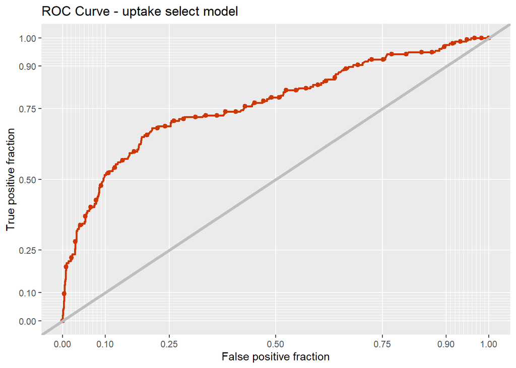

```r
ggplot(testProbs.sel, aes(d = as.numeric(testProbs.sel$Outcome), m = Probs)) +
  geom_roc(n.cuts = 50, labels = FALSE, colour = "orangered3") +
  style_roc(theme = theme_grey) +
  geom_abline(slope = 1, intercept = 0, size = 1.5, color = 'grey') +
  labs(title = "ROC Curve - uptake select model")
```

```r
pROC::auc(testProbs.sel$Outcome, testProbs.sel$Probs)
```

```
## Area under the curve: 0.767
```

## Cross-validation of Both Models

We ran a 100-fold cross-validation of our model to obtain the distributions of accuracy metrics such as the specificity, sensitivity, and the AUC for the ROC curve. We visualize this distribution in the charts below. The tighter that each distribution is to its mean, the more generalizable the model.

At the .5 threshold the ROC is only slightly tighter for the select model than the kitchen sink model. The same is true for the specificity of each model, which are quite spread, implying that our model iis not well optimized. The sensitivity however is tight for both models, so it does do a good job at generalizing the rate of true positives across the folds.

The main takeaway is that the predictive power of our model needs to be increased to offset the effect that it will have when we relate it to the cost-benefit analysis of our housing subsidy uptake use-case.

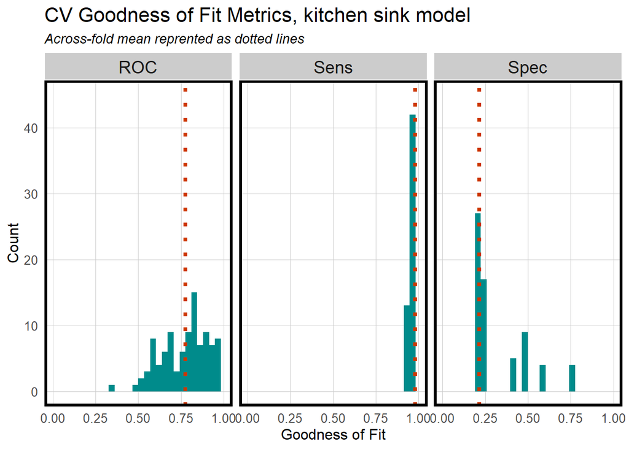

```r
ctrl <- trainControl(method = "cv", number = 100, classProbs=TRUE, summaryFunction=twoClassSummary)

cvFit.ks <- train(y ~ ., data = housingSubsidy %>%
                                   dplyr::select(-X, -y_numeric, -education, -taxLien,
                                  -employed, -poutcome.suc,
                                  -last.contact, -inflation.high, -older,
                                  -spent.less),
                method="glm", family="binomial",
                metric="ROC", trControl = ctrl)

cvFit.sel <- train(y ~ ., data = housingSubsidy %>%
                                   dplyr::select(-X, -y_numeric,
                                                 #-previous,
                                  -job, -taxbill_in_phl, -poutcome,
                                  -marital, -education, -mortgage, -day_of_week,
                                  -taxLien, -pdays, #-campaign,
                                  -inflation_rate,
                                  -spent_on_repairs),
                method="glm", family="binomial",
                metric="ROC", trControl = ctrl)

#displaying metrics

dplyr::select(cvFit.ks$resample, -Resample) %>%
  gather(metric, value) %>%
  left_join(gather(cvFit.ks$results[2:4], metric, mean)) %>%
  ggplot(aes(value)) +
    geom_histogram(bins=30, fill = "cyan4") +
    facet_wrap(~metric) +
    geom_vline(aes(xintercept = mean), colour = "orangered3", linetype = 3, size = 1.5) +
    scale_x_continuous(limits = c(0, 1)) +
    labs(x="Goodness of Fit", y="Count", title="CV Goodness of Fit Metrics, kitchen sink model",
         subtitle = "Across-fold mean reprented as dotted lines") +
    plotTheme()
```

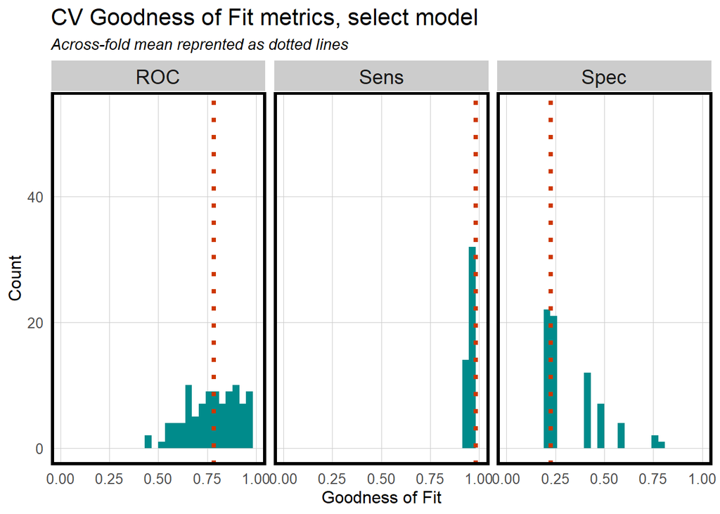

```r
dplyr::select(cvFit.sel$resample, -Resample) %>%
  gather(metric, value) %>%
  left_join(gather(cvFit.sel$results[2:4], metric, mean)) %>%
  ggplot(aes(value)) +
    geom_histogram(bins=30, fill = "cyan4") +
    facet_wrap(~metric) +
    geom_vline(aes(xintercept = mean), colour = "orangered3", linetype = 3, size = 1.5) +
    scale_x_continuous(limits = c(0, 1)) +
    labs(x="Goodness of Fit", y="Count", title="CV Goodness of Fit metrics, select model",
         subtitle = "Across-fold mean reprented as dotted lines") +
    plotTheme()
```

# Cost-benefit analysis

Up to this point we have used a threshold of .5 to test the performance of our model. The code and visualizations below are used to determine what threshold would be the best to use in our model to predict who would use the housing subsidy or not. Our approach now is to generate confusion metrics using different thresholds, and to calculate total revenue for each from the perspective of the Housing Subsidy program’s costs and benefits. Assumptions are summarized below. To our understanding, the greatest marginal benefit is in maximizing the number of true negatives, optimizing for program uptake and money saved.

To run a cost benefit analysis using our model, we assume that 25% of homeowners who we predict as true positives will actually accept it when contacted. We count the $10,000 premium as the benefit, and the $5,000 subsidy and $2,850 in marketing and outreach as the costs. Because our data lacks spatial features, we exclude the neighboring home premium in the cost-benefit calculation but it is important to note.

Assumptions:

- $10,000 home premium for each accepted credit
- $2,850 in marketing cost for each contact
- $5,000 repair subsidy for each accepted credit
- 25% of contacted homeowners accept credit

Cost/benefit equations:

- **True positive:** When the model correctly predicts that a homeowner will take the credit; marketing resources were allocated, and 25% of homeowners took the credit, resulting in a $\$10,000 - (\$5,000 + \$2,850) = \$2,150$ return for the 25% of cases that accepted the credit. We spend $2,850 on 75% of cases, who were sent the offer but did not take the credit.
  - Equation: $(\$10,000 - \$7,850) * ($true positives$\times 0.25) + (-\$2,850 \times ($true positives$\times 0.75))$
- **True negative:** Predicted correctly homeowner would not take the credit, no marketing resources were allocated, no credit was allocated: **$0**
- **False positive:** Predicted incorrectly that a homeowner would take the credit; allocated marketing resources; no credit allocated: **-$2850**
  - Equation: $-\$2,850 \times$false positives
- **False negative:** Predicted that a homeowner would not take the credit but they did. These are homeowners who likely signed up for reasons unrelated to the marketing campaign. We ‘0 out’ this category, assuming the cost/benefit of this is **$0**, because this analysis is primarily concerned with the performance of the outreach process.

In short, investments from governments look like losses on the books but it is important to take into account all of the effects that it can have when considering its value.

## create the ‘Cost/benefit table’

```r
cost_benefit_table <-
   testProbs.sel %>%
      count(predOutcome, Outcome) %>%
      summarize(True_Positive = sum(n[predOutcome==1 & Outcome==1]),
                True_Negative = sum(n[predOutcome==0 & Outcome==0]),
                False_Positive = sum(n[predOutcome==1 & Outcome==0]),
                False_Negative = sum(n[predOutcome==0 & Outcome==1])) %>%
       gather(Variable, Count) %>%
       mutate(Revenue =
               case_when(Variable == "True_Positive"  ~ ((10000 - 7850) * (Count*.25)) + (-2850 * (Count*.75)),
                         Variable == "True_Negative"  ~ 0,
                         Variable == "False_Positive" ~ (-2850)*Count,
                         Variable == "False_Negative" ~ 0)) %>%
    bind_cols(data.frame(Description = c(
              "Predicted credit uptake correctly; allocated marketing resources, and 25% took the credit.",
              "Predicted no credit uptake correctly, no marketing resources were allocated, and no credit was allocated.",
              "Predicted credit uptake incorrectly; allocated marketing resources, no credit allocated.",
              "Predicted no credit uptake incorrectly. Homeowners likely signed up for reasons unrelated to marketing campaign. We assume the cost/benefit of this is $0.")))

kable(cost_benefit_table) %>%
  kable_styling(font_size = 12, full_width = F,
                bootstrap_options = c("striped", "hover", "condensed")) %>%
  footnote(general_title = "\n")
```

| Variable | Count | Revenue | Description |
| --- | --- | --- | --- |
| True_Positive | 35 | -56000 | Predicted credit uptake correctly; allocated marketing resources, and 25% took the credit. |
| True_Negative | 1255 | 0 | Predicted no credit uptake correctly, no marketing resources were allocated, and no credit was allocated. |
| False_Positive | 28 | -79800 | Predicted credit uptake incorrectly; allocated marketing resources, no credit allocated. |
| False_Negative | 122 | 0 | Predicted no credit uptake incorrectly. Homeowners likely signed up for reasons unrelated to marketing campaign. We assume the cost/benefit of this is $0. |

## Plot of Confusion Metrics per Threshold

Based on our assumptions, we want to find the threshold that can limit the most costly errors from a business standpoint. The ideal threshold returns the greatest cost/benefit. To determine which threshold would be best, we iterate through each threshold between .01 and 1, calculate the confusion metrics, and then the total revenue for each.

The following plot visualizes the confusion matrix, showing the trade-offs made in our model. False negatives and true negatives generate 0 costs and 0 (measurable) benefits at all thresholds.

At lower thresholds, more homeowners are predicted to accept the credit, thus more money is spent on outreach. Moreover, false positive results generate higher costs to HCD. True positive results have the same trend, although its slope is less steep because each generates $10,000, offsetting the marketing cost.

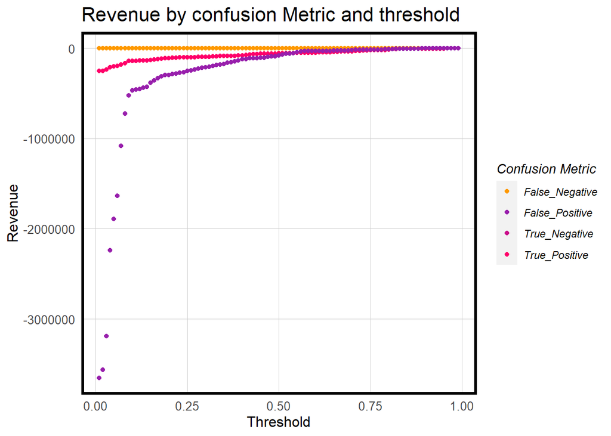

```r
iterateThresholds <- function(data) {
  x = .01
  all_prediction <- data.frame()
  while (x <= 1) {

  this_prediction <-
      testProbs.sel %>%
      mutate(predOutcome = ifelse(Probs > x, 1, 0)) %>%
      count(predOutcome, Outcome) %>%
      summarize(True_Negative = sum(n[predOutcome==0 & Outcome==0]),
                True_Positive = sum(n[predOutcome==1 & Outcome==1]),
                False_Negative = sum(n[predOutcome==0 & Outcome==1]),
                False_Positive = sum(n[predOutcome==1 & Outcome==0])) %>%
     gather(Variable, Count) %>%
     mutate(Revenue =
               ifelse(Variable == "True_Negative", Count * 0,
               ifelse(Variable == "True_Positive",((10000 - 7850) * (Count * .25)) + (-2850 * (Count * .75)),
               ifelse(Variable == "False_Negative", 0 * Count,
               ifelse(Variable == "False_Positive", (-2850) * Count, 0)))),
            Threshold = x)

  all_prediction <- rbind(all_prediction, this_prediction)
  x <- x + .01
  }
return(all_prediction)
}

whichThreshold <- iterateThresholds(testProbs_r3)

whichThreshold_revenue <-
whichThreshold %>%
    group_by(Threshold) %>%
    summarize(Revenue = sum(Revenue))

#plot
whichThreshold %>%
  ggplot(.,aes(Threshold, Revenue, colour = Variable)) +
  geom_point() +
  scale_colour_manual(values = palette5[c(5, 1:3)]) +
  labs(title = "Revenue by confusion Metric and threshold",
       y = "Revenue") +
  plotTheme() +
  guides(colour=guide_legend(title = "Confusion Metric"))
```

```r
#calculate revenue and number of credits allocated
whichThreshold_revenue <-
  whichThreshold %>%
    mutate(actualcreditno = ifelse(Variable == "True_Negative" | Variable == "False_Positive", Count,
                                   ifelse(Variable == "True_Positive", Count*.75, 0)),
           actualcredityes = ifelse(Variable == "True_Positive", (Count * .25),
                                    ifelse(Variable == "False_Negative", Count, 0)),
           total_TP = ifelse(Variable == "True_Positive", Count, 0),
           total_FN = ifelse(Variable == "False_Negative", Count, 0)) %>%
    group_by(Threshold) %>%
    summarize(Revenue = sum(Revenue),
              creditsGiven = sum(actualcredityes),
              falseNegative = sum(total_FN),
              truePositive = sum(total_TP))
whichThreshold_revenue <- whichThreshold_revenue %>%
  mutate(TP_rate = truePositive/creditsGiven)


#whichThreshold_revenue[1:50,]

maxrevenueTest <- whichThreshold_revenue[,1:3]
```

## Per Threshold: Total Revenue and Total Credit Count

The revenue plot flattens out after a threshold of 0.86. The plot of credits given out begins to flatten out at the same threshold. So, in the 0.86 to 0.96 range, they are both maximized, which fulfills the dual goals of minimizing cost and maximizing credits allocated. If we were to optimize solely for these outcomes, we should use any of the thresholds within this range.

Within this range, credits are almost entirely given out to people who presumably found and applied for the credit on their own. However, our model is not explicitly optimized for reaching people who did not know about the program. If HCD wants to prioritize minimizing loss, it may use a threshold between 0.88 and 0.95. But if it wants to reach homeowners without knowledge of the program while generating as much real estate value as possible, it may instead consider using a very low threshold, despite the fact that it would result in many false positives.

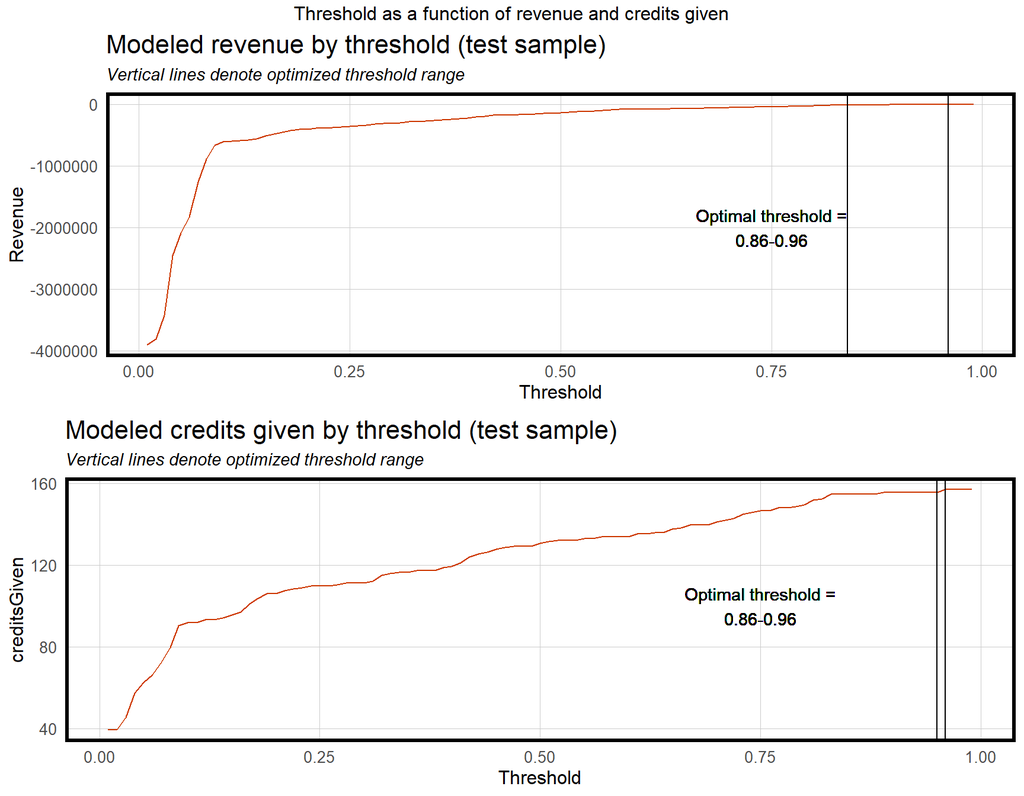

```r
p1 <-
  ggplot(whichThreshold_revenue)+
  geom_line(aes(x = Threshold, y = Revenue), color="orangered3")+
  geom_vline(xintercept =  pull(arrange(whichThreshold_revenue, -Revenue)[1,1]))+
  geom_vline(xintercept =  pull(arrange(whichThreshold_revenue, -Revenue)[13,1]))+
  geom_text(aes(x=0.75, label=paste0("Optimal threshold =\n", "0.86-0.96"), y=-2000000))+
    labs(title = "Modeled revenue by threshold (test sample)",
         subtitle = "Vertical lines denote optimized threshold range") +
   plotTheme()

p2 <-
  ggplot(whichThreshold_revenue)+
  geom_line(aes(x = Threshold, y = creditsGiven), color="orangered3")+
  geom_vline(xintercept =  pull(arrange(whichThreshold_revenue, -creditsGiven)[1,1]))+
    geom_vline(xintercept =  pull(arrange(whichThreshold_revenue, -creditsGiven)[11,1]))+
    geom_text(aes(x=0.75, label=paste0("Optimal threshold =\n", "0.86-0.96"), y=100))+
    labs(title = "Modeled credits given by threshold (test sample)",
         subtitle = "Vertical lines denote optimized threshold range") +
   plotTheme()

 grid.arrange(p1, p2, ncol =1, top = "Threshold as a function of revenue and credits given")
```

## Threshold Table: Total Revenue and Total Count of Credits

The following table helps us put numbers to the importance of choosing an optimal threshold rather than simply using 50%. There is a clear decrease in cost to the agency when we use the optimal threshold, and the amount of credits used is above what 50% would have generated. There is no contest between the two, the model with .86 as the threshold optimizes for the loss of revenue and for the total credits taken significantly better. This is despite the fact that the model itself is not powerful enough by our standards, because we can select a threshold we can still outperform the random business-as-usual approach.

```r
threshold_table <- whichThreshold_revenue[c(86, 50), c("Threshold", "Revenue", "creditsGiven")]
threshold_table %>%
  group_by(Threshold) %>%
  kable(caption = "Total revenue and credits given by threshold level", col.names = c("Threshold", "Total Revenue", "Total Count of Credits")) %>%
    kable_styling("striped", full_width = T)
```

Total revenue and credits given by threshold level

| Threshold | Total Revenue | Total Count of Credits |
| --- | --- | --- |
| 0.86 | -7650 | 154.75 |
| 0.50 | -135800 | 130.75 |

# Conclusion

Our model has a limited ability to predict true positives, when a homeowner enters the program in the interest of receiving a tax credit. Our training data set was skewed towards negative outcomes, throwing off our ability to predict positives better. Ont he other hand we could predict true negatives well. The model also does not account for the location of outcomes. It is very possible that neighbors, in speaking with each other, can influence each others decisions about uptake. They could even share the information with someone for the first time, which would be great from the department’s perspective if it has the goal of outreach to people that do not know about the program.

The program could benefit from graphic design investment. Although the city wants to minimize costs, it would only take the cost of 2 false positives (invest in outreach that yields no return) to create marketing material that could persuade a recipient to take it or talk about it with neighbors. Reminding people about the relationship between their investment (the use of the subsidy) to the value of their community could also increase uptake rates. Furthermore, based on our exploratory analysis, we believe that the department should increase outreach in March, September, and October. It should also reach out through cell phones instead of home phones, which is more in step with modern times, and to look at economic trends such as inflation to determine if it is a good time from the consumer’s perspective to invest with that subsidy. For instance, if the prices of materials wipe out the benefit of the subsidy then uptake does not make sense.

Again, our ability to analyze what threshold would be best makes our approach better than the business as usual approach. However, our model itself would be improved with better feature engineering and understanding about the interplay between the characteristics of consumers, their government, barriers to entry, and their relationship to their home and community. With a better model, our optimal threshold would yield better results for our total revenue and uptakes. Government should maximize equity and social cohesion to provide us, its clients, with great places to call home.